# Time Series Analysis

#### - Plot 1:

[figure not shown]

```r
Box.test(vec.ts, lag =20, type="Ljung-Box")
```

```
##
##  Box-Ljung test
##
## data:  vec.ts
## X-squared = 1475, df = 20, p-value < 2.2e-16
```

Q2: Is there a significant seasonal component?? #### - Plot 2:

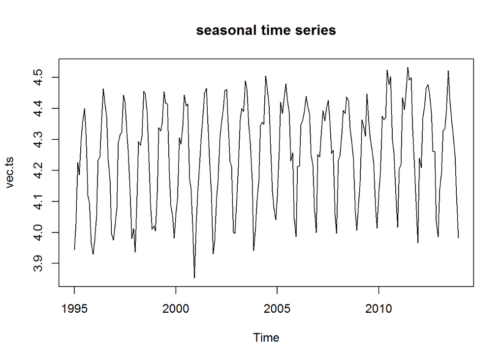

```r
plot(vec.ts, main = 'seasonal time series')
```

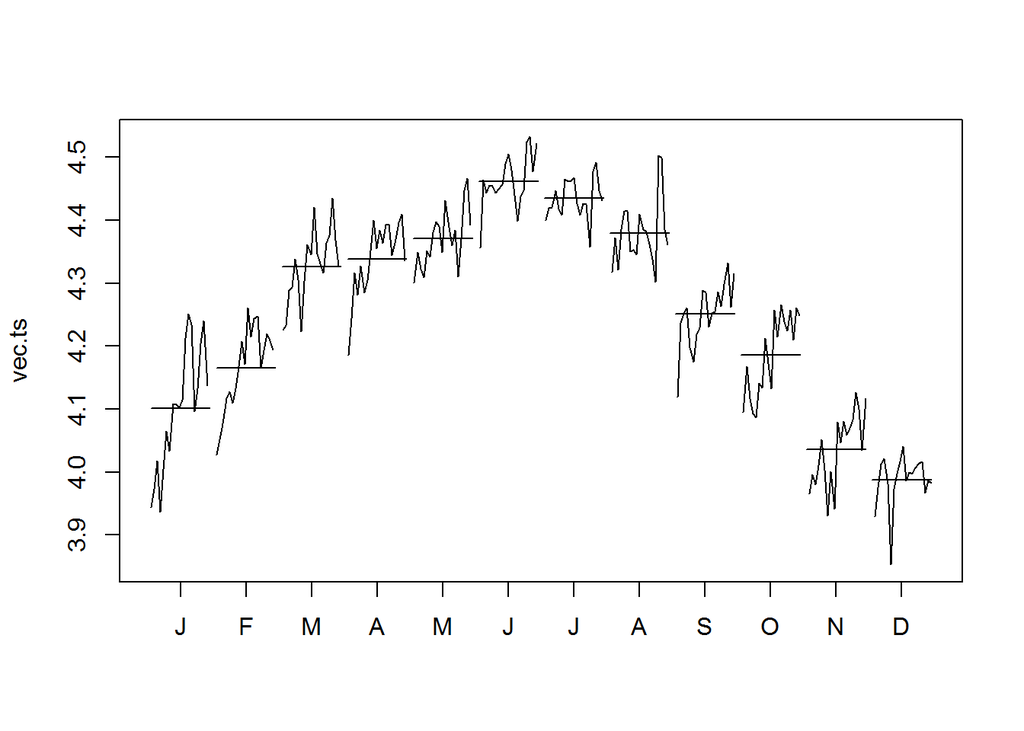

```r
monthplot(vec.ts)
```

**Result:** Based on the above results, **time series is a significant seasonal component**.

Q3: For the residual from the STL decomposition of the time series what is the order of the ARMA(p,q) process that best fits?

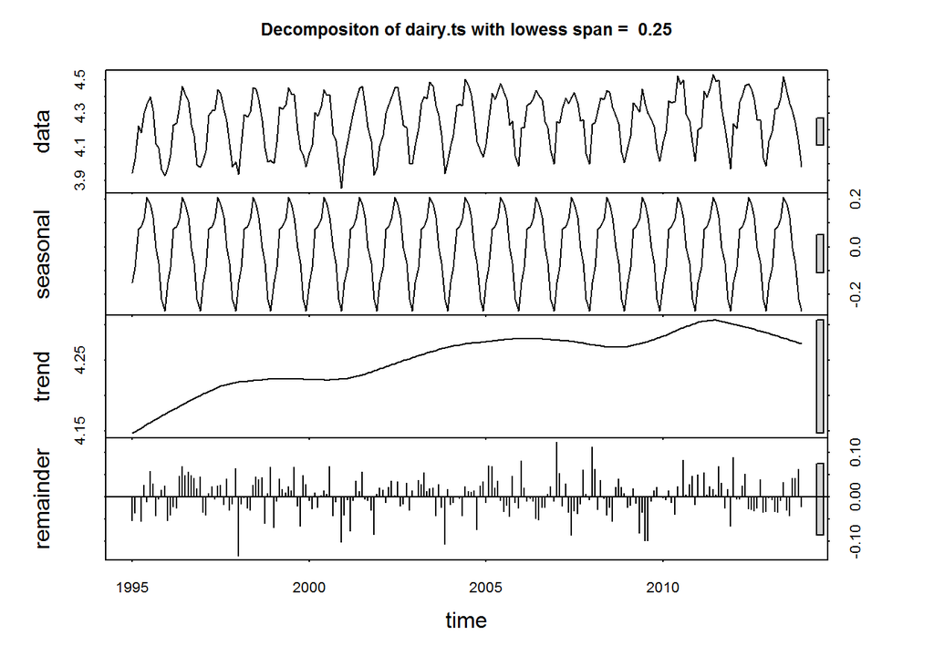

```r
## Decomposition of the time series into components
ts.decomp <- function(df, col = 'dairy.ts', span = 0.25, Mult = TRUE, is.df = TRUE){
  # if(Mult) temp = log(df[, col])  else temp = ts(df[, col]
  if(is.df) temp = log(df[, col])
  else temp = df
  spans = span * length(temp)
  fit <- stl(temp, s.window = "periodic", t.window = spans)
  plot(fit, main = paste('Decompositon of',col,'with lowess span = ', as.character(span)))
  fit$time.series
}

temp = ts.decomp(vec.ts, is.df = FALSE, Mult = FALSE)
```

#### - Plot 3:

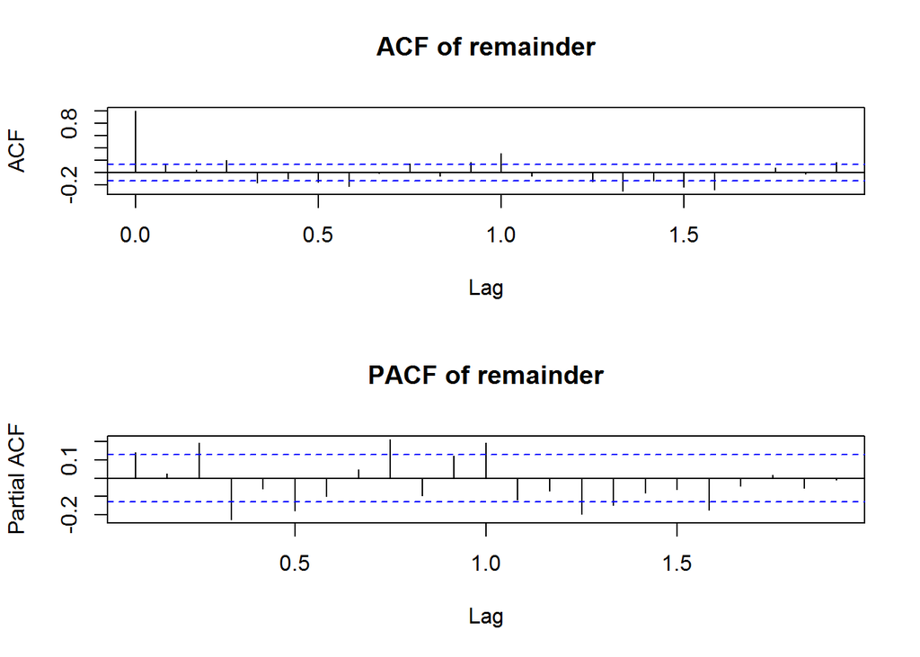

```r
plot.acf(temp[,3],is.df=FALSE)
```

```r
iceCream.arima = ts.model(temp[, 3], col = 'ARIMA model for icecream production', order = c(2,0,2))##
```

```
##
## Call:
## arima(x = ts, order = order, include.mean = FALSE)
##
## Coefficients:
##           ar1      ar2     ma1     ma2
##       -1.6287  -0.7684  1.7825  0.8681
## s.e.   0.0967   0.0852  0.0900  0.0823
##
## sigma^2 estimated as 0.001481:  log likelihood = 418.91,  aic = -827.83
```

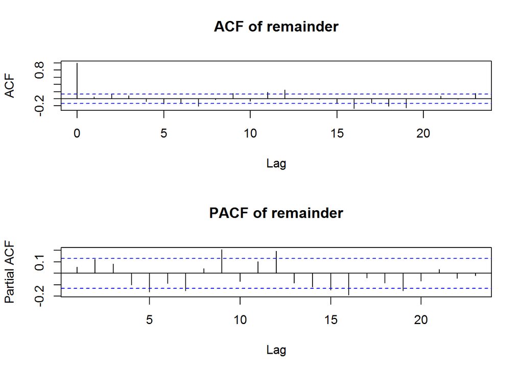

```r
plot.acf(iceCream.arima$resid[-1],is.df=FALSE)
```

**Result:** Based on the above results, we are getting best fit at order c(2,0,2) for the ARMA(p,q) process.

**Q4:** Forecast production for 12 months. Report both numeric values and plot the confidence intervals.

- Are the confidence intervals reasonably small compared to the forecast means?
- How do the confidence intervals behave as time moves to the future?

```r
fit.icecream = auto.arima(vec.ts, max.p=3, max.q=3,
                       max.P=2, max.Q=2, max.order=5, max.d=2, max.D=1,
                       start.p=0, start.q=0, start.P=0, start.Q=0)
summary(fit.icecream)
```

```
## Series: vec.ts
## ARIMA(3,0,1)(0,1,2)[12] with drift
##
## Coefficients:
##           ar1     ar2     ar3     ma1     sma1     sma2  drift
##       -0.1996  0.1658  0.3746  0.4086  -0.5043  -0.2039  6e-04
## s.e.   0.1767  0.0755  0.0636  0.1925   0.0699   0.0672  2e-04
##
## sigma^2 estimated as 0.001583:  log likelihood=389.7
## AIC=-763.4   AICc=-762.7   BIC=-736.4
##
## Training set error measures:
##                       ME       RMSE        MAE        MPE      MAPE
## Training set 0.001360524 0.03809705 0.02972694 0.02906281 0.7001261
##                   MASE         ACF1
## Training set 0.7583233 -0.004410837
```

```r
icecream.forecast = forecast(fit.icecream, h=12)
summary(icecream.forecast)
```

```
##
## Forecast method: ARIMA(3,0,1)(0,1,2)[12] with drift
##
## Model Information:
## Series: vec.ts
## ARIMA(3,0,1)(0,1,2)[12] with drift
##
## Coefficients:
##           ar1     ar2     ar3     ma1     sma1     sma2  drift
##       -0.1996  0.1658  0.3746  0.4086  -0.5043  -0.2039  6e-04
## s.e.   0.1767  0.0755  0.0636  0.1925   0.0699   0.0672  2e-04
##
## sigma^2 estimated as 0.001583:  log likelihood=389.7
## AIC=-763.4   AICc=-762.7   BIC=-736.4
##
## Error measures:
##                       ME       RMSE        MAE        MPE      MAPE
## Training set 0.001360524 0.03809705 0.02972694 0.02906281 0.7001261
##                   MASE         ACF1
## Training set 0.7583233 -0.004410837
##
## Forecasts:
##          Point Forecast    Lo 80    Hi 80    Lo 95    Hi 95
## Jan 2014       4.159970 4.108976 4.210965 4.081981 4.237960
## Feb 2014       4.233898 4.181801 4.285995 4.154223 4.313574
## Mar 2014       4.354554 4.302074 4.407033 4.274293 4.434814
## Apr 2014       4.378331 4.322309 4.434353 4.292653 4.464010
## May 2014       4.417831 4.361797 4.473864 4.332135 4.503527
## Jun 2014       4.517751 4.461459 4.574044 4.431659 4.603843
## Jul 2014       4.462807 4.406146 4.519469 4.376151 4.549463
## Aug 2014       4.409070 4.352409 4.465731 4.322414 4.495726
## Sep 2014       4.319325 4.262580 4.376070 4.232540 4.406109
## Oct 2014       4.259274 4.202501 4.316048 4.172446 4.346103
## Nov 2014       4.116758 4.059984 4.173532 4.029930 4.203587
## Dec 2014       4.010205 3.953413 4.066997 3.923350 4.097061
```

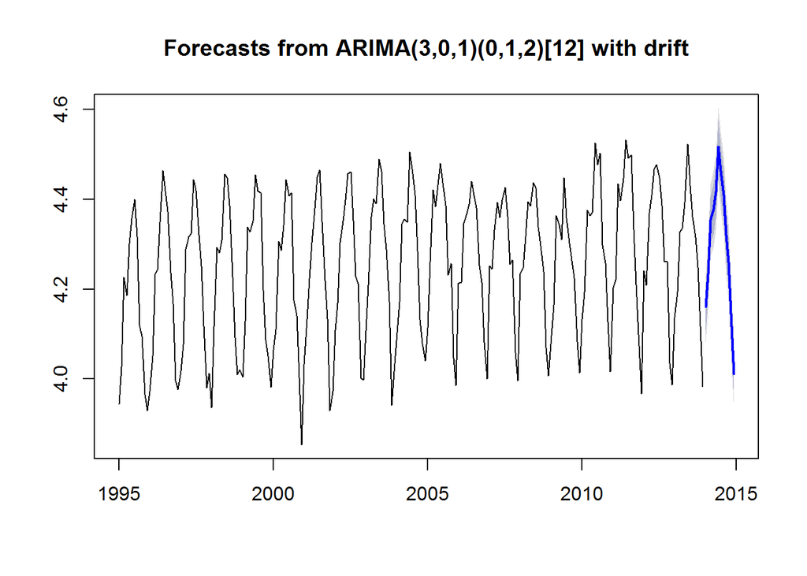

```r
plot(icecream.forecast)
```

#### Conclusion:

Based on the above results, Confidence intervals are relatively small and they behave as the time moves.